# Final Project Analysis

Brooks Groharing

5/14/2021

### 1.

#### Are there differences in gene expression between the experimental conditions (temperature, pupal stage, genotype)?

The short answer is yes, for all variables. For each of the three sources of variation, I’ve generated some volcano plots to visualize the distribution of upregulated/downregulated/unaffected gens (see below).

I’ve also saved lists of specific differentially expressed genes, and the effect on their expression due to:

**Effect due to Temperature:**

```
## [1] "4142 genes are differentially expressed based on temperature."
```

```
## [1] "Top 5 DE genes at 25C"
```

| Gene | logFC | p (adjusted) | Average Reads |
| --- | --- | --- | --- |
| LysX | -6.800911 | 0.0000002 | 3.520494 |
| CG10911 | -6.397827 | 0.0000112 | 2.795407 |
| CG3868 | -6.347468 | 0.0005331 | 4.129604 |
| Victoria | -6.291890 | 0.0000000 | -2.164442 |
| CG32633 | -6.189875 | 0.0000020 | 2.876572 |

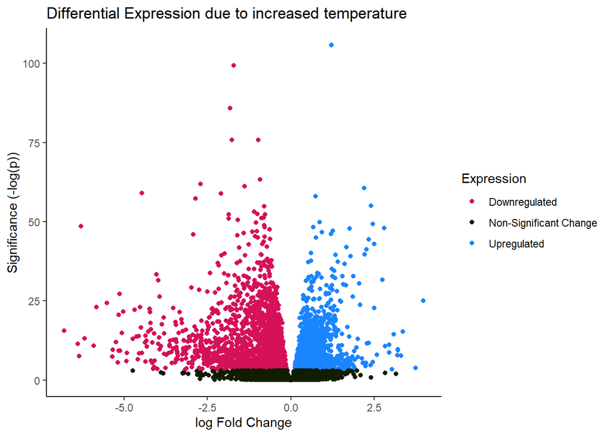

**Effect due to Pupal Stage:**

```
## [1] "8548 genes are differentially expressed in p7"
```

```
## [1] "Top 5 DE genes in Pupal Stage 7"
```

| Gene | logFC | p (adjusted) | Average Reads |
| --- | --- | --- | --- |
| Osi3 | 16.42197 | 0 | 2.133096 |
| Osi12 | 16.18263 | 0 | 3.273656 |
| CG34244 | -15.46068 | 0 | 4.302291 |
| Osi22 | 15.42388 | 0 | 1.399515 |
| Osi9 | 15.27430 | 0 | 5.654898 |

```
## [1] "8887 genes are differentially expressed in p12"
```

```
## [1] "Top 5 DE genes in Pupal Stage 12"
```

| Gene | logFC | p (adjusted) | Average Reads |
| --- | --- | --- | --- |
| CG14147 | 13.36296 | 0e+00 | 1.500028 |
| Cpr64Ab | 13.11531 | 0e+00 | 1.949177 |
| Osi19 | 13.08545 | 2e-07 | 2.687515 |
| CG34205 | 12.89586 | 0e+00 | 4.472983 |
| CG13048 | 12.88530 | 0e+00 | 1.663468 |

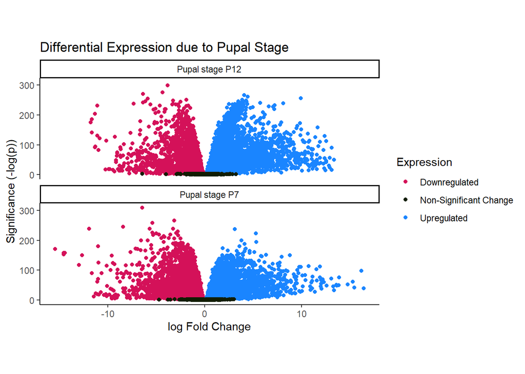

**Effect due to Genotype:**

```
## [1] "2311 genes are differentially expressed in 11123"
```

```
## [1] "Top 5 DE genes for strain 11123"
```

| Gene | logFC | p (adjusted) | Average Reads |
| --- | --- | --- | --- |
| CG11912 | 9.214473 | 0.0003398 | 2.888724 |
| Victoria | -8.703407 | 0.0000000 | -2.164442 |
| Grik | -8.333393 | 0.0000000 | 4.324510 |
| CG12951 | 8.303180 | 0.0000000 | -2.034676 |
| CG12057 | 8.164879 | 0.0000003 | -1.736270 |

```
## [1] "2839 genes are differentially expressed in 11150"
```

```
## [1] "Top 5 DE genes for strain 11150"
```

| Gene | logFC | p (adjusted) | Average Reads |
| --- | --- | --- | --- |
| Victoria | -8.794352 | 0 | -2.1644425 |
| Sgs5bis | 8.265688 | 0 | -2.1310550 |
| CG17105 | -7.514245 | 0 | 0.5996365 |
| PGRP-LA | 7.343489 | 0 | 3.9658372 |
| CG32631 | 7.054924 | 0 | -0.1116948 |

```
## [1] "2957 genes are differentially expressed in 11322"
```

```
## [1] "Top 5 DE genes for strain 11322"
```

| Gene | logFC | p (adjusted) | Average Reads |
| --- | --- | --- | --- |
| Victoria | -8.580677 | 0.0000000 | -2.164442 |
| Grik | -8.072935 | 0.0000000 | 4.324510 |
| CG9040 | 8.039040 | 0.0000000 | -2.287027 |
| Tengl1 | 7.571463 | 0.0000000 | -2.137348 |
| CG7290 | -7.073077 | 0.0045691 | -1.868975 |

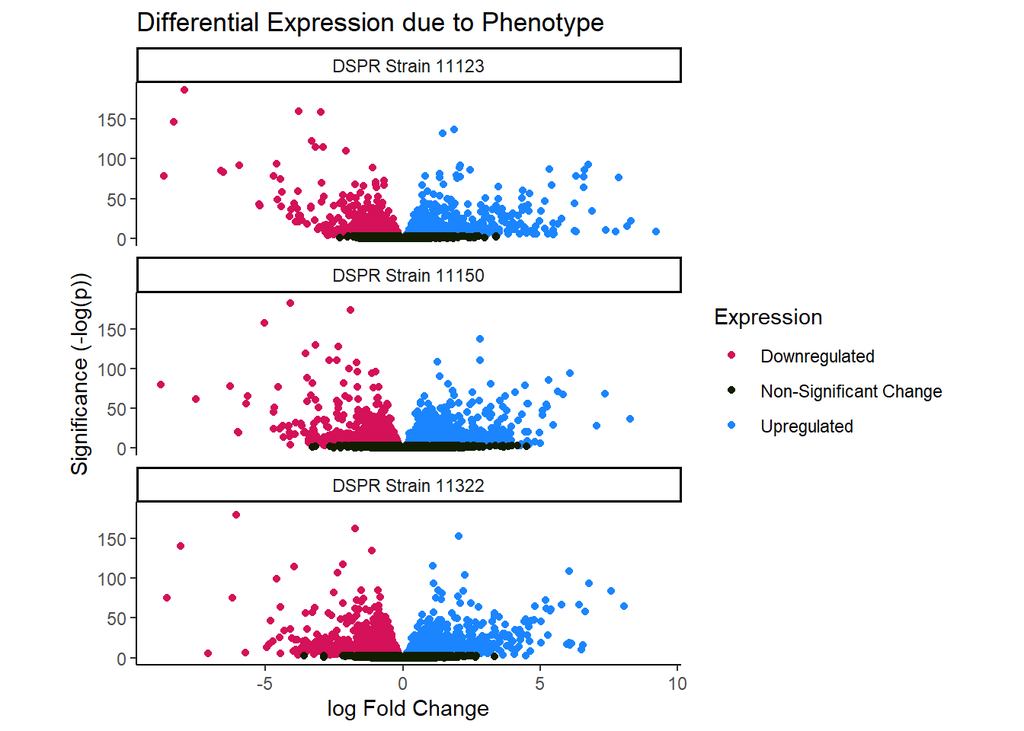

#### How many reads per sample are there on average?

```
## [1] "Mean expression, across all genes: 1.06"
```

**Top 5 expressed genes:**

| Gene | Average Reads |
| --- | --- |
| eEF1alpha1 | 12.91610 |
| Fbp1 | 12.21424 |
| Act5C | 12.05620 |
| alphaTub84B | 11.90466 |
| eEF2 | 11.88372 |

**Bottom 5 expressed genes:**

[output not shown]

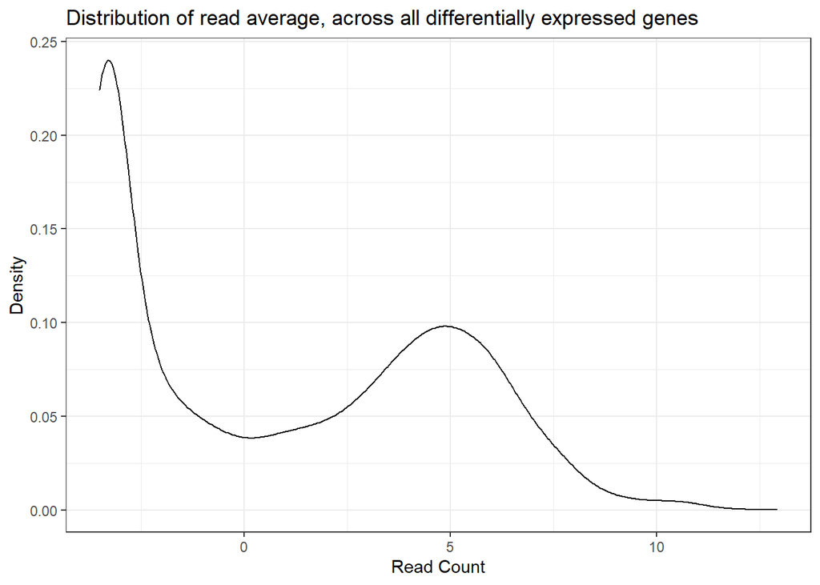

For the full list of gene expression averages, see AverageExpressionTable.txt.

### 2.

#### How should the sequencing data be handled? There are technical replicates. Should they be combined into one long file, or should each technical replicate be analyzed separately and then combined?

To assess this, I essentially recapitulated the analysis above, but using results files pooled by lane. I decided against including volcano plots for the pooled data (There is code to generate and print them in the source .rmd; I’ve just commented it out.)

I was able to identify significantly fewer DE genes when pooling the technical replicates, regardless of the source of variation. Interestingly, the pupal stages seemed less affected by pooling than the temperature or strain effect, at least in terms of gene count.

| Varying factor | DE Genes (separate) | DE Genes (pooled) | % change |
| --- | --- | --- | --- |
| Rearing at 25C | 4142 | 240 | -94.21 |
| Pupal Stage 7 | 8548 | 5649 | -33.91 |
| Pupal Stage 12 | 8887 | 6589 | -25.86 |
| Strain 11123 | 2311 | 244 | -89.44 |
| Strain 11150 | 2839 | 321 | -88.69 |
| Strain 11322 | 2957 | 369 | -87.52 |

The vast majority of the time, if just one of the methods fails to identify a DE expressed gene which the other catches, it’s using the pooled replicates model. In other words, DE genes are “lost” almost exclusively when pooling replicates, and not the other way around.

It’s interesting that the small number of exceptions–that is, genes differentially expressed only after pooling–happened only in pupal stage models. That said, none of them are shared between p7/p12.

*Genes which ‘appeared’ as DE only when pooling:*

| Pupal Stage 7 |
| --- |
| bcd |
| CG6300 |
| Ir52a |
| lncRNA:CR44298 |
| lncRNA:CR44442 |
| lncRNA:CR44769 |
| lncRNA:CR44994 |
| lncRNA:CR45452 |
| lncRNA:CR46230 |

| Pupal Stage 12 |
| --- |
| asRNA:CR43472 |
| asRNA:CR44020 |
| CG13930 |
| CG15024 |
| CG18586 |
| halo |
| Ir48a |
| lncRNA:CR44564 |
| lncRNA:CR44888 |
| Tep5Psi |
| Ugt35E2 |

The fact that these genes, in particular, are only significant when pooling lanes is probably due to chance. At the very least, my analysis didn’t offer any clear explanation.

I also wanted to assess the difference in differential expression, within each category of variation, between the separate and pooled methods. The next plot maps these distributions. (Negative values of x correspond to a negative shift in the pooled model, and vice versa)

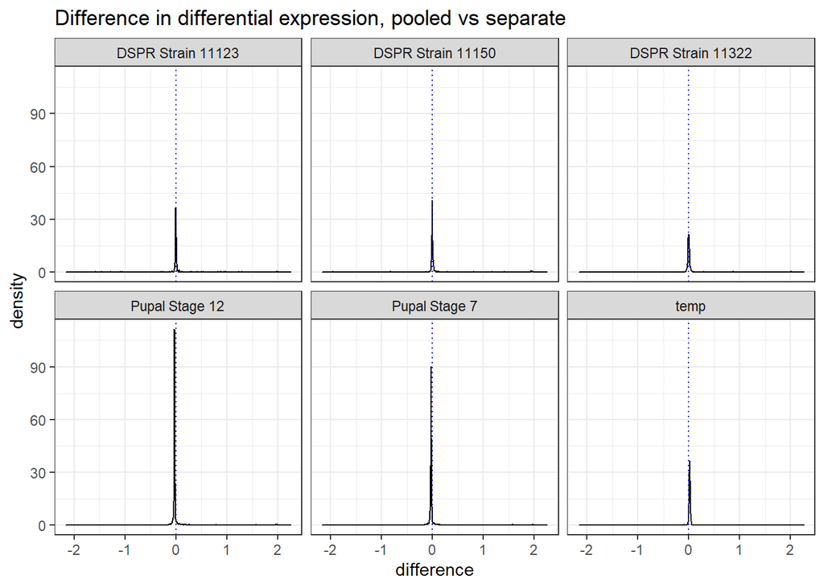

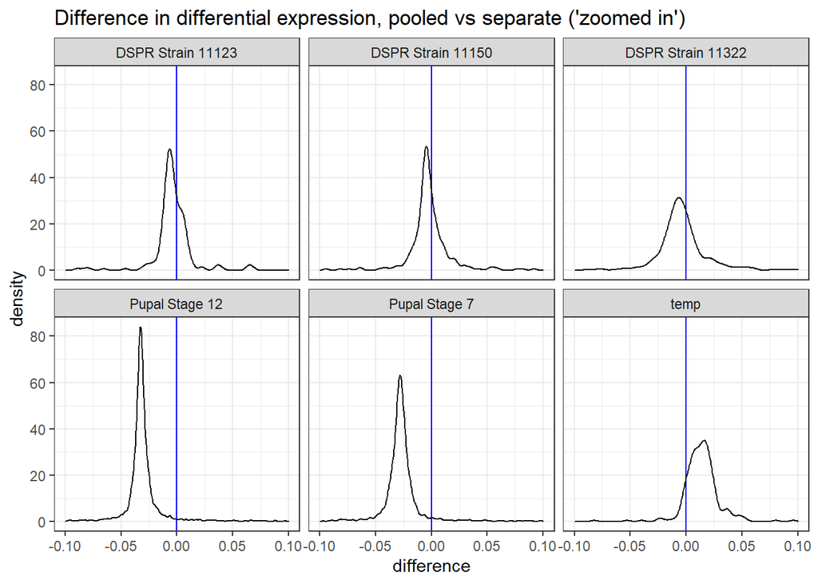

*In summary:* There are definitely noticeable differences when choosing to pool the technical replicates vs analyzing them as separate files. The pooled method recognizes genes as being differentially expressed far less frequently than the separate file method. It also tends to shift logFC in one direction or the other, on a per-variable basis.

The lane replicates should be processed separately and combined, to minimize the loss of legitimate differentially expressed genes in the final results.